# Maximum Likelihood & Optimisation

Matthew Talluto

02.05.2022

# What is a likelihood?

- In the Zombie example, we knew the probability of being a zombie $p = 0.3$
- We wanted to know the probability of observing some number of zombies $k$ in a sample of $n=10$
- More frequently, we observe $k$ and $n$, and want to know $p$.

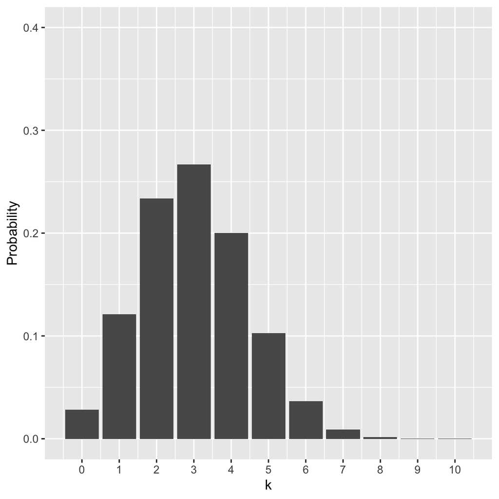

# Sampling a population

- We sampled a large population to determine the rate of zombism.
- Assume samples were random, *iid*
- Given a sample of $n=25$, we observed $k=7$ zombies.
- Estimate $p$, the proportion of the population that is a zombie.

# Sampling a population

- We sampled a large population to determine the rate of zombism.
- Assume samples were random, *iid*
- Given a sample of $n=25$, we observed $k=7$ zombies.
- Estimate $p$, the proportion of the population that is a zombie.
- *Intuitively*, we know the best estimate is $p = 7/25 = 0.28.$ Why?

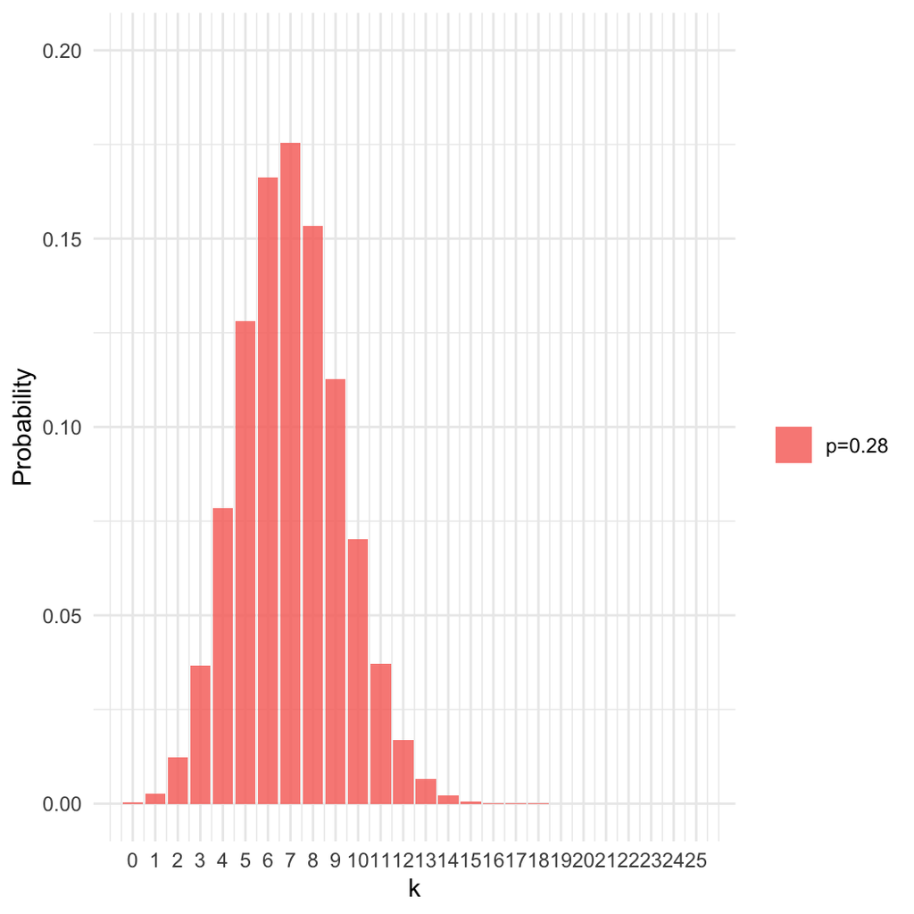

# Sampling a population

- We sampled a large population to determine the rate of zombism.
- Assume samples were random, *iid*
- Given a sample of $n=25$, we observed $k=7$ zombies.
- Estimate $p$, the proportion of the population that is a zombie.
- *Intuitively*, we know the best estimate is $p = 7/25 = 0.28.$ Why?
- Many other values of $p$ are also possible.

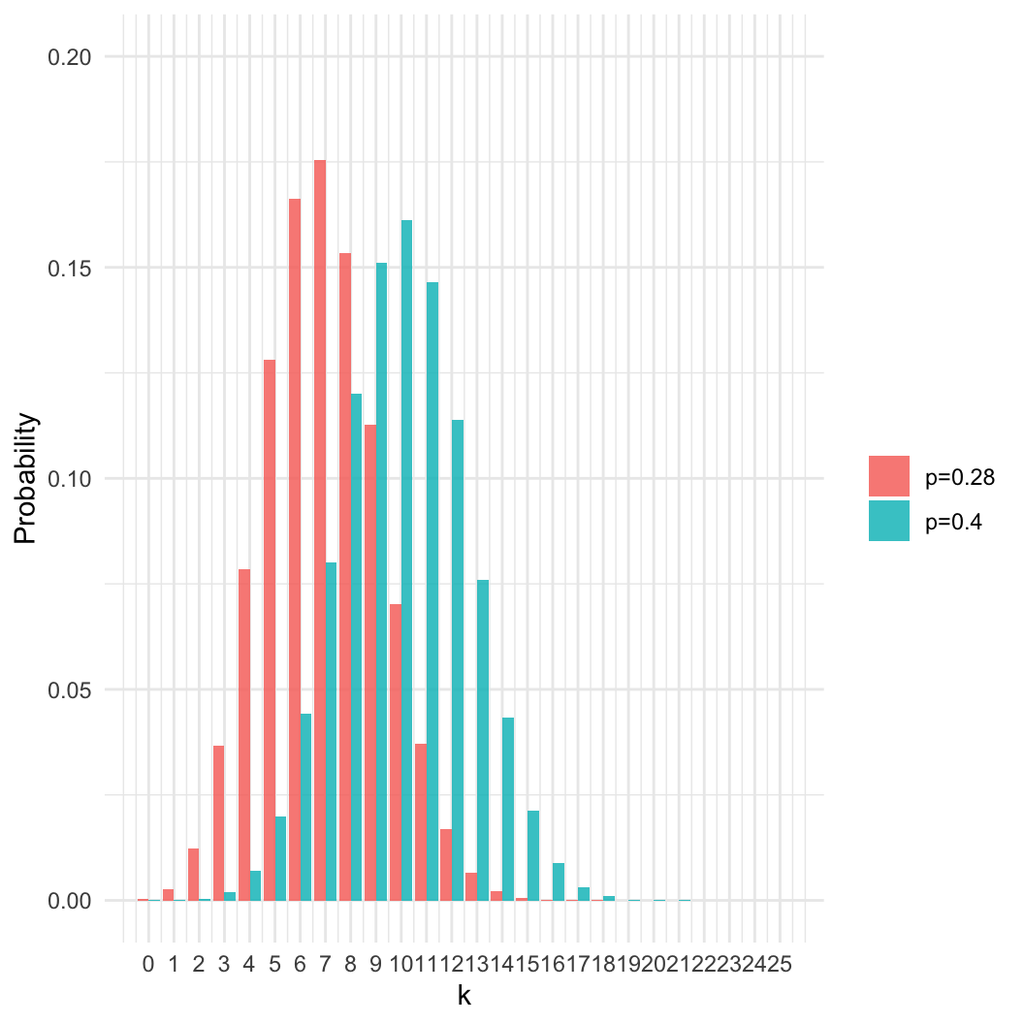

# Likelihood functions

- The **likelihood function** is a function *f* of the data $X$ and model/parameters $\theta$
- Here $X = \{k,n\}$ and $\theta = \{p\}$
- $f(X,\theta)$ returns the *probability of observing* $X$, given a particular model $\theta$: $pr(X|\theta)$
- Here, the *binomial PMF* is a useful likelihood function
- $n=25$, $k=7$

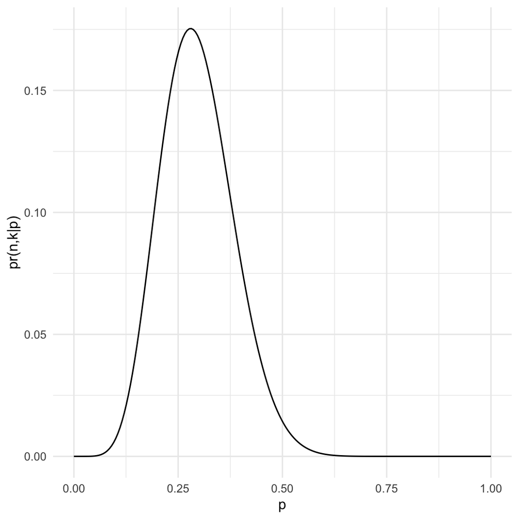

```r
p = seq(0,1,length.out=200)
n = 25
k = 7
dat = data.frame(p = p, lhood = dbinom(k, n, p))
pl = ggplot(dat, aes(x = p, y = lhood)) + geom_line() +
  theme_minimal() + ylab("pr(n,k|p)")
pl
```

# Likelihood functions

- Intuition is fine, but how do we estimate or (in some cases) solve for the maximum likelihood?
- $n=25$, $k=7$

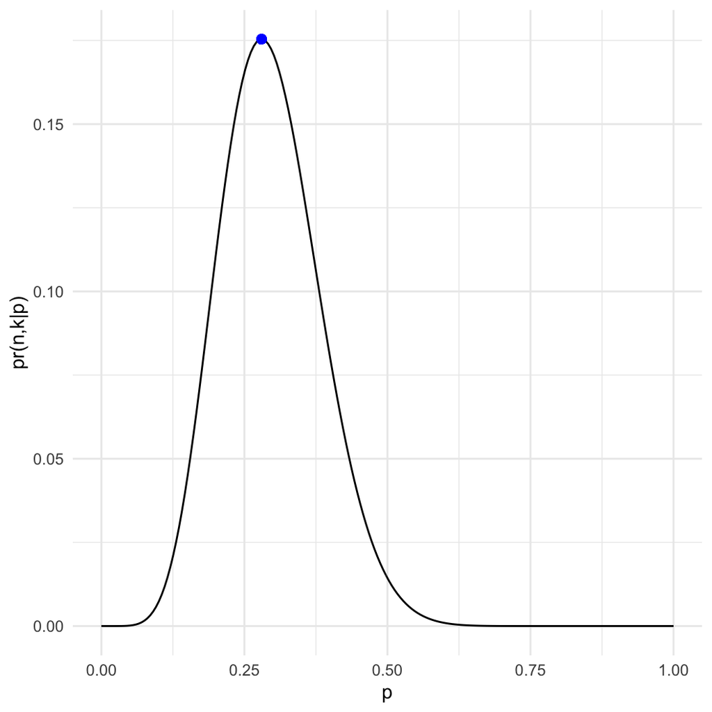

# Solving for the MLE

$$\begin{aligned}
\mathcal{L}(k,n|p) & = {n \choose k} p^k(1-p)^{(n-k)} \\
\frac{d \mathcal{L}(k,n|p)}{dp} & = {n \choose k}kp^{k-1}(1-p)^{(n-k)} - {n \choose k} p^k (n-k)(1-p)^{(n-k-1)} \\
& = 0
\end{aligned}$$

# Solving for the MLE

$$\begin{aligned}
{n \choose k} p^k (n-k)(1-p)^{(n-k-1)} & = {n \choose k}kp^{k-1}(1-p)^{(n-k)} \\
p(p^{k-1}) (n-k)(1-p)^{(n-k-1)} & = kp^{k-1}(1-p)(1-p)^{(n-k-1)} \\
p (n-k) & = k(1-p) \\
pn -pk & = k-pk \\
pn & = k \\
p & = \frac{k}{n} \\
\end{aligned}$$

# Optimisation

- In many (most) cases, analytical solutions are unavailable or impractical.
- We turn to various algorithms for numerical optimisation

# Optimisation

- In many (most) cases, analytical solutions are unavailable or impractical.
- We turn to various algorithms for numerical optimisation

```r
n = 25
k = 7
lfun = function(p, n, k) {
  dbinom(k, n, p, log=TRUE) ## why log??
}
p_init = 0.5
optim(p_init, lfun, method = "Brent", n = n, k = k, control = list(fnscale = -1), lower=0, upper=1)
```

```
## $par
## [1] 0.28
##
## $value
## [1] -1.740834
##
## $counts
## function gradient
##       NA       NA
##
## $convergence
## [1] 0
##
## $message
## NULL
```

# Generalising to multiple observations

- Remember the product rule: for two independent events, $pr(A,B) = pr(A)pr(B)$
- Likelihoods are probabilities, and we like to assume each data point is independent. Thus:

$$\mathcal{L}(X_{1..n}|\theta) = \prod_{i=1}^{n} \mathcal{L}(X_i|\theta)$$

```r
n_vec = c(25, 12, 134)
k_vec = c(7, 4, 27)
lfun = function(p, n, k) {
  sum(dbinom(k, n, p, log=TRUE)) ## why log?? why sum??
}
p_init = 0.5
optim(p_init, lfun, method = "Brent", n = n_vec, k = k_vec, control = list(fnscale = -1), lower=0, upper=1)
```

```
## $par
## [1] 0.2222222
##
## $value
## [1] -6.419546
##
## $counts
## function gradient
##       NA       NA
##
## $convergence
## [1] 0
##
## $message
## NULL
```

# Why Bayes?

- I want to describe some phenomenon (“model”; $\theta$)
- I have some general (“prior”) knowledge about the question: $pr(\theta)$
- I gather additional information (“data”; $X$)

What is the probability that my model is correct given what I already know about it and what I’ve learned?

$$pr(\theta | X)$$

# Applying Bayes’ Theorem

- We already know an expression for this:

$$pr(\theta | X) = \frac{pr(X|\theta)pr(\theta)}{pr(X)}$$

# Applying Bayes’ Theorem

- We already know an expression for this:

$$pr(\theta | X) = \frac{pr(X|\theta)pr(\theta)}{pr(X)}$$

- The goal, $pr(\theta | X)$, is called the **posterior probability of $\theta$**
- We have already seen $pr(X|\theta)$; this is the **likelihood** of the data
- $pr(\theta)$ is often called the **prior probability of $\theta$**. Could also be called “other information about $\theta$”
- What about $pr(X)$? This is the **normalizing constant**

When we do Bayesian inference, each of these terms is a full **probability distribution**

# The normalizing constant

- For the zombie example, we had a single observation (“I tested positive”), we were able to add up all of the ways one could test positive.
- $pr(T) = pr(T|Z)pr(Z) + pr(T|Z')pr(Z')$
- $pr(X) = \sum_i^n pr(X|\theta_i)pr(\theta_i)$ where all possible models are in the set $n$
- What about for continuous problems? There are an infinte number of possible models if $pr(\theta)$ is a continuous PDF.

# The normalizing constant

- For the zombie example, we had a single observation (“I tested positive”), we were able to add up all of the ways one could test positive.
- $pr(T) = pr(T|Z)pr(Z) + pr(T|Z')pr(Z')$
- $pr(X) = \sum_i^n pr(X|\theta_i)pr(\theta_i)$ where all possible models are in the set $n$
- What about for continuous problems? There are infinitely many possible datasets if X is real-valued, and infinte possible models if $pr(\theta)$ is a continuous PDF.

$$pr(X) = \int_a^b pr(X|\theta)pr(\theta)d \theta$$

- This integral can be challenging to compute

# Proportional Bayes’ Theorem

- $pr(X)$ is a *constant*; it adjusts the height of the distribution so that the posterior integrates to 1
- If all we want to do is estimate the maximum value, we can safely ignore it

# Proportional Bayes’ Theorem

- $pr(X)$ is a *constant*; it adjusts the height of the distribution so that the posterior integrates to 1
- If all we want to do is estimate the maximum value, we can safely ignore it

$$pr(\theta|X) \propto pr(X|\theta)pr(\theta)$$

# Maximum A Posteriori Estimation

- $pr(X)$ is a *constant*; it adjusts the height of the distribution so that the posterior integrates to 1
- If all we want to do is estimate the maximum value, we can safely ignore it

$$pr(\theta|X) \propto pr(X|\theta)pr(\theta)$$

- This is know as the **maximum a posteriori** (MAP) estimate, Bayesian equivalent to the MLE

```r
n = 25
k = 7
log_lfun = function(p, n, k) {
  dbinom(k, n, p, log=TRUE)
}
log_prior = function(p, alpha, beta) {
  dbeta(p, alpha, beta, log = TRUE)
}
log_posterior = function(p, n, k, alpha, beta) {
  log_lfun(p, n, k) + log_prior(p, alpha, beta)  ## why +?
}

## starting value for the optimisation
p_init = 0.5

## we choose an "uninformative" prior
alpha = 1
beta = 1
```

# Maximum A Posteriori Estimation

```r
optim(p_init, log_posterior, method = "Brent", n = n,
      k = k, alpha = alpha, beta = beta,
      control = list(fnscale = -1), lower=0, upper=1)
```

```
## $par
## [1] 0.28
##
## $value
## [1] -1.740834
##
## $counts
## function gradient
##       NA       NA
##
## $convergence
## [1] 0
##
## $message
## NULL
```

This prior has no influence on the posterior

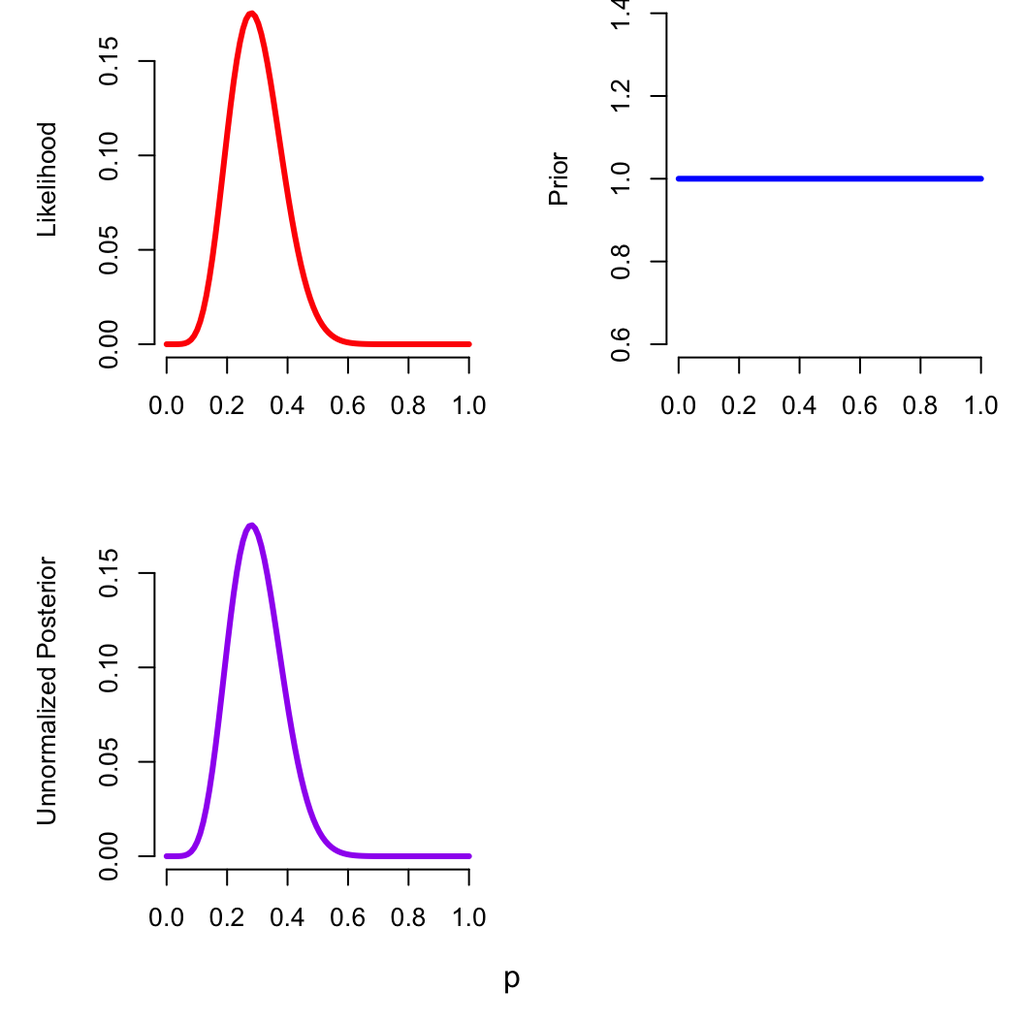

# Changing the prior

```r
alpha = 2; beta = 2
optim(p_init, log_posterior, method = "Brent", n = n,
      k = k, alpha = alpha, beta = beta,
      control = list(fnscale = -1), lower=0, upper=1)$par
```

```
## [1] 0.2962963
```

```r
alpha2 = 3; beta2 = 1.5
optim(p_init, log_posterior, method = "Brent", n = n,
      k = k, alpha = alpha2, beta = beta2,
      control = list(fnscale = -1), lower=0, upper=1)$par
```

```
## [1] 0.3272727
```

This prior is informative, but relatively weak (our data has the weight equivalent to `alpha=7, beta=18`)

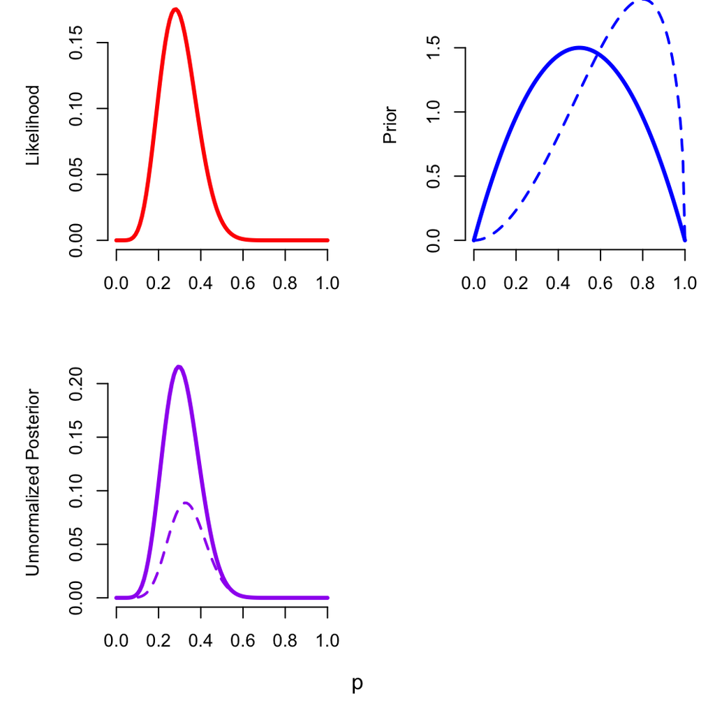

# Changing the prior

What if we had already conducted an identical prior sample, with 20 zombies and 5 normals?

```r
alpha3 = 20; beta3 = 5
optim(p_init, log_posterior, method = "Brent", n = n,
      k = k, alpha = alpha3, beta = beta3,
      control = list(fnscale = -1), lower=0, upper=1)$par
```

```
## [1] 0.5416667
```

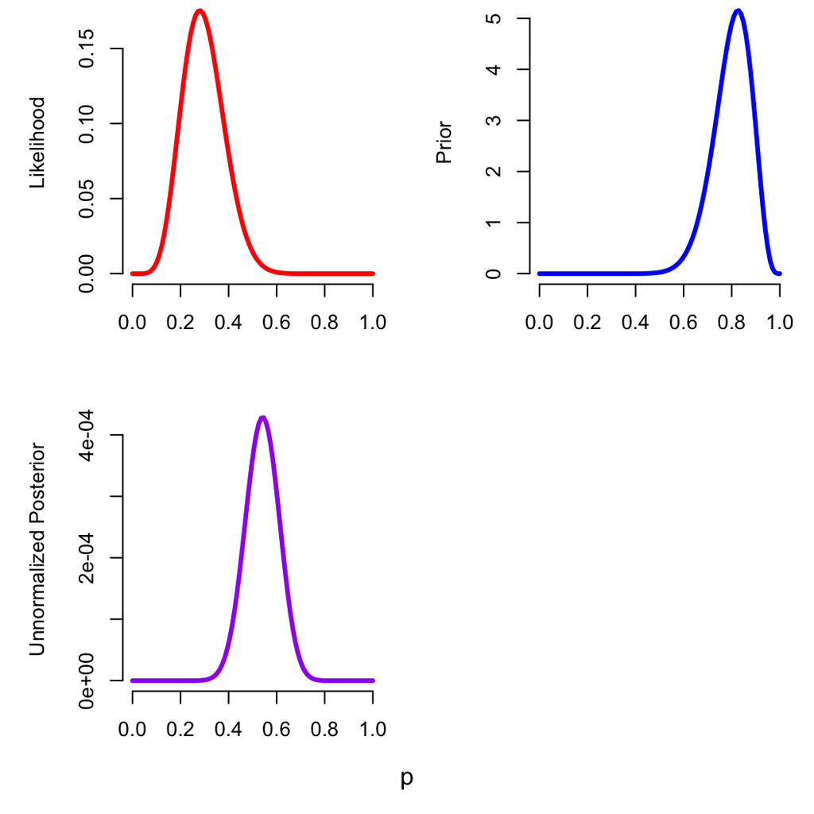

# Geting a normalized posterior

- We often want to know the full posterior distribution
- For some problems, we have analytical solutions to $\int pr(X|\theta)pr(\theta)d \theta$

# Geting a normalized posterior

- We often want to know the full posterior distribution
- For some problems, we have analytical solutions to $\int pr(X|\theta)pr(\theta)d \theta$
- For the beta-binomial, if:

$$\begin{aligned}
pr(p) & = \mathrm{Beta}(\alpha, \beta) \\
pr(k,n | p) & = \mathrm{Binomial}(k, n, p)
\end{aligned}$$

# Geting a normalized posterior

- We often want to know the full posterior distribution
- For some problems, we have analytical solutions to $\int pr(X|\theta)pr(\theta)d \theta$
- For the beta-binomial, if:

$$\begin{aligned}
pr(p) & = \mathrm{Beta}(\alpha, \beta) \\
pr(k,n | p) & = \mathrm{Binomial}(k, n, p) \\
pr(p | k,n,\alpha, \beta) &= \mathrm{Beta}(\alpha + k, \beta + n - k)
\end{aligned}$$

# Geting a normalized posterior

- We often want to know the full posterior distribution
- For some problems, we have analytical solutions to $\int pr(X|\theta)pr(\theta)d \theta$
- In many cases, the shape of the log posterior is appoximately quadratic (the posterior is approximately normal)
- **Laplace approximation** (or Quadratic approximation) is a method for approximating the shape of this curve

# Geting a normalized posterior

- We often want to know the full posterior distribution
- For some problems, we have analytical solutions to $\int pr(X|\theta)pr(\theta)d \theta$
- In many cases, the shape of the log posterior is appoximately quadratic (the posterior is approximately normal)
- **Laplace approximation** (or Quadratic approximation) is a method for approximating the shape of this curve

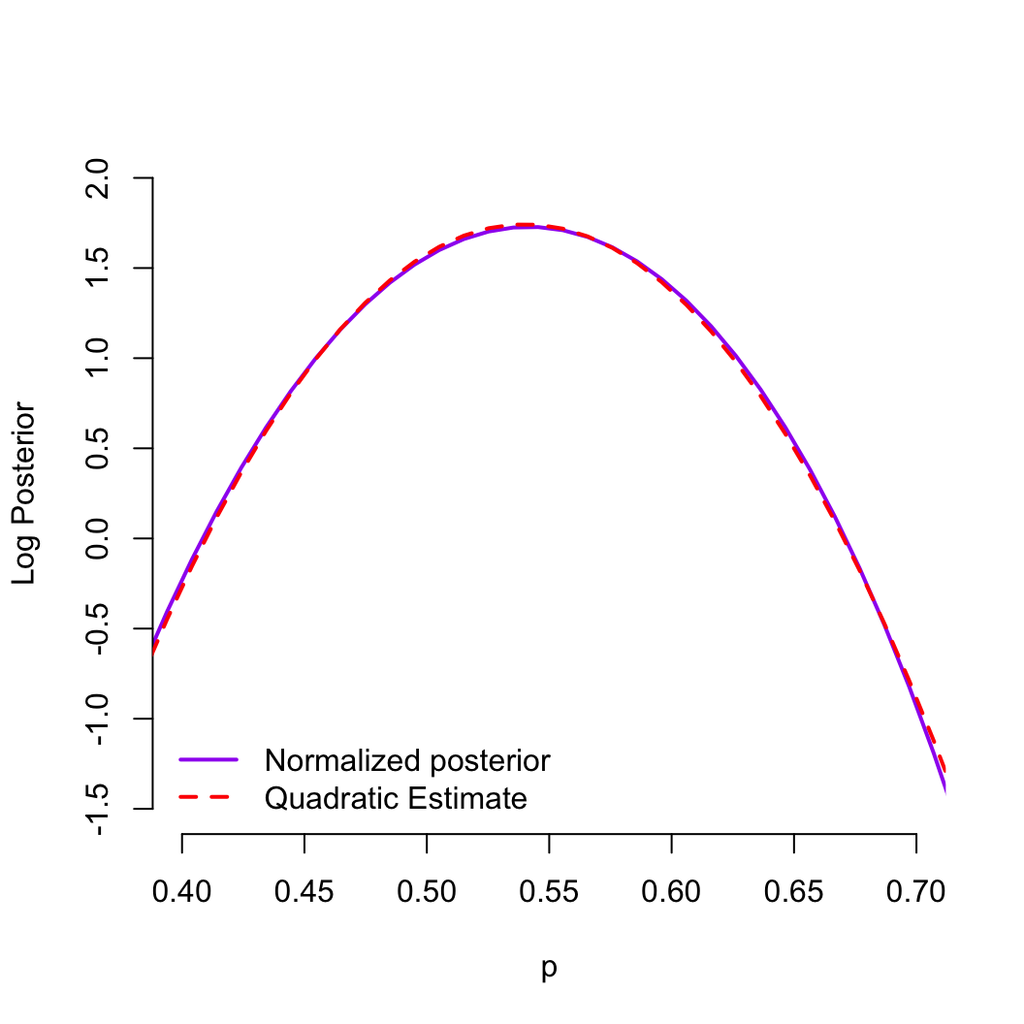

# Geting a normalized posterior

- We often want to know the full posterior distribution
- For some problems, we have analytical solutions to $\int pr(X|\theta)pr(\theta)d \theta$
- In many cases, the shape of the log posterior is appoximately quadratic (the posterior is approximately normal)
- **Laplace approximation** (or Quadratic approximation) is a method for approximating the shape of this curve
- When the above are unavailable, we can use simulations (e.g., MCMC)